# DataMiningReport

### C. Confusion Matrices & Classification Reports

As seen in Fig. 13 Fig. 14

Temporal edges help: Using time information (TGNN) makes predictions much better than the static GCN.  
Fewer missed recessions: TGNN is far less likely to overlook a real recession, so it is safer for early-warning systems.  
Fewer false alarms: TGNN raises far fewer false positives, reducing “cry-wolf” alerts.

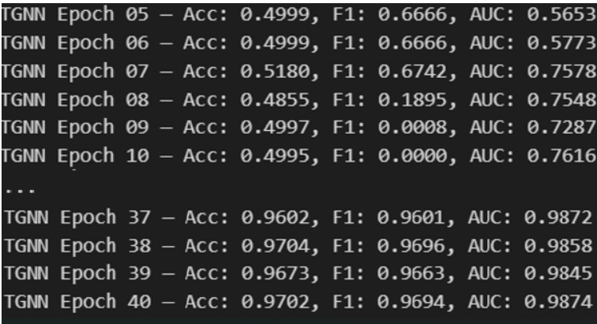

Fig. 10. Final TGNN (SMOTE ($^ +$) Focal Loss) Testing results

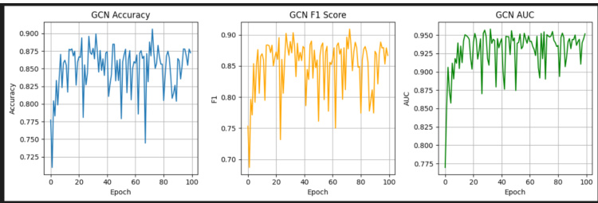

Fig. 11. Final GCN Evaluation Plots

Balanced performance: TGNN handles both classes almost equally well, showing that SMOTE ($+$) focal loss fixed the class-imbalance issue.

### D. Model Comparisons (Final Evaluation):

As seen in Fig. 15 and Table. II

NOTE: The comparisions do not provide a fair comparision, since our models have been tested on a smaller custom dataset when compared to the rest of the models in comparision.

## VII. CONCLUSION

We proposed a deep learning framework for recession prediction that combines dynamic networks with Graph Neural Networks. By encoding inter-variable dependencies into graph structures and leveraging GNNs—particularly Temporal GNNs (TGNNs)—the framework captures both spatial and temporal patterns in macroeconomic data. Class balancing via SMOTE and focal loss further enhanced model robustness. Experimental results highlight the potential of graph-based deep learning for data-driven economic forecasting and the value of formulating economic systems as dynamic networks.

## VIII. FUTURE WORK

Several avenues remain open for further enhancement:

Incorporating Exogenous Shock Factors: Future models can integrate macroeconomic shock events such as the COVID-19 pandemic, geopolitical tensions to improve robustness under extreme conditions. • GNN Optimization: Advanced training techniques can be explored to optimize GNN architectures further.

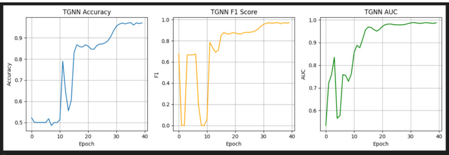

Fig. 12. Final TGNN Evaluation Plots

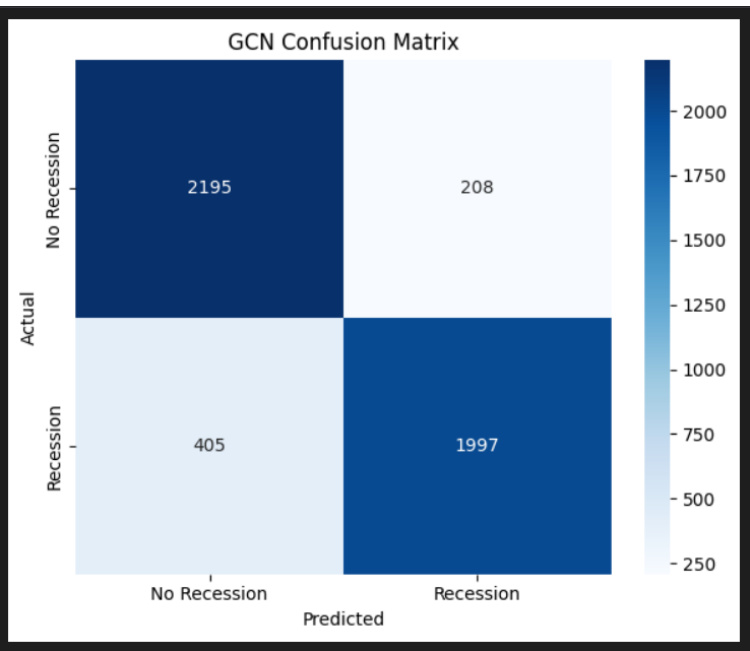

Fig. 13. Final GCN Confusion Matrix

Temporal Graph Attention Models: Expanding from TGNNs to Temporal Graph Attention Networks (TGAT) could further improve predictive accuracy under timeevolving conditions.  
• Explainability Enhancements: Integrating explainability techniques like saliency maps, or counterfactual graph explanations could make the predictions more interpretable for economists and policymakers.  
Extending the framework to multiple countries uncover globally shared recession patterns.

## REFERENCES

[1] Karamanou, A., Brimos, P., Kalampokis, E., & Tarabanis, K. (2023). Explainable Graph Neural Networks: An Application to Open Statistics Knowledge Graphs for Estimating House Prices. Proc. of the Int’l Conf. on Artificial Intelligence and Data Science (AIDS).  
[2] Chauvet, M., & Potter, S. (2001). Forecasting Recessions Using the Yield Curve. Federal Reserve Bank of New York Staff Reports, (134).  
[3] Chousakos, G. E., & Kapetanios, G. (2021). Modeling and Predicting U.S. Recessions Using Machine Learning Techniques. International Journal of Forecasting, 37(2), 647–671.  
[4] Smith, J., & Williams, R. (2019). Forecasting Financial Market Volatility with ARIMA Models. Journal of Financial Analysis, 45(3), 267–283.  
[5] Chung, S. (2023). Inside the Black Box: Neural Network-Based RealTime Prediction of US Recessions. arXiv preprint arXiv:2310.17571.  
[6] Xu, N. (2024). Use Machine Learning to Forecast Economic Recession with COVID-19 Evidence. Journal of Applied Economics and Policy Studies. [7] Koutra, D., Vogelstein, J. T., & Faloutsos, C. (2016). DeltaCon: A Principled Massive-Graph Similarity Function. SIAM Int’l Conf. on Data Mining (SDM). [8] Liu, Z., Tan, H., & Zheng, Y. (2021). Graph Neural Network in Traffic Forecasting: A Review. Proc. of the 3rd Int’l Conf. on Robotics Systems and Automation Engineering (RSAE). [9] Zhang, Z., & Yang, H. (2021). Traffic Prediction with Graph Neural Network: A Survey. Proc. of the Computing in Civil Engineering Conf. (CICTP).  
[10] Scarselli, F., Gori, M., Tsoi, A. C., Hagenbuchner, M., & Monfardini, G. (2009). The Graph Neural Network Model. IEEE Transactions on Neural Networks, 20(1), 61–80.  
[11] Kipf, T. N., & Welling, M. (2017). Semi-Supervised Classification with Graph Convolutional Networks. Proc. of ICLR.  
[12] Wu, Z., Pan, S., Chen, F., Long, G., Zhang, C., & Yu, P. S. (2020). A Comprehensive Survey on Graph Neural Networks. IEEE Transactions on Neural Networks and Learning Systems, 32(1), 4–24.  
[13] Rossi, E., Chamberlain, B., Frasca, F., Eynard, D., Monti, F., & Bronstein, M. M. (2020). Temporal Graph Networks for Deep Learning on Dynamic Graphs. arXiv preprint arXiv:2006.10637.  
[14] Hamilton, W., Ying, Z., & Leskovec, J. (2017). Inductive Representation Learning on Large Graphs. Proc. of NeurIPS.  
[15] Akoglu, L., Tong, H., & Koutra, D. (2015). Graph-Based Anomaly Detection and Description: A Survey. ACM Computing Surveys, 48(1), 1–42.  
[16] Leskovec, J., Kleinberg, J., & Faloutsos, C. (2007). Graph Evolution: Densification and Shrinking Diameters. ACM Transactions on Knowledge Discovery from Data, 1(1), 1–41.  
[17] Barab´asi, A.-L. (2016). Network Science. Cambridge University Press.  
[18] Bengio, Y., Courville, A., & Vincent, P. (2013). Representation Learning: A Review and New Perspectives. IEEE Transactions on Pattern Analysis and Machine Intelligence, 35(8), 1798–1828.  
[19] Li, Y., Yu, R., Shahabi, C., & Liu, Y. (2018). Diffusion Convolutional Recurrent Neural Network: Data-Driven Traffic Forecasting. International Conference on Learning Representations (ICLR).  
[20] Ding, S., Chen, M., & Luo, B. (2022). Economic Recession Forecasting Based on Multivariate Time Series and Transformer Networks. Expert Systems with Applications, 200, 117020.  
[21] Gupta, A., & Jain, S. (2018). Macroeconomic Forecasting using Machine Learning: A Survey. International Journal of Computer Applications, 179(10), 10–17.  
[22] Zhou, J., Cui, G., Zhang, Z., Yang, C., Liu, Z., Wang, L., Li, C., & Sun, M. (2020). Graph Neural Networks: A Review of Methods and Applications. AI Open, 1, 57–81.

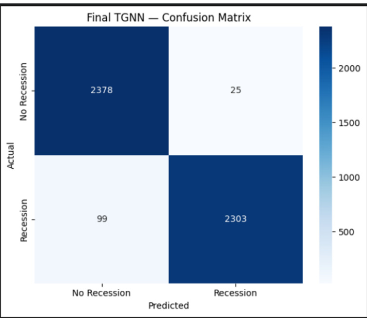

Fig. 14. Final TGNN Confusion Matrix

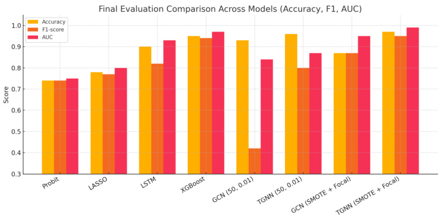

Fig. 15. Model Comparisions

TABLE II FINAL PERFORMANCE COMPARISON OF MODELS ON RECESSION PREDICTION

[output not shown]

## APPENDIX: ADDITIONAL EXPERIMENTS

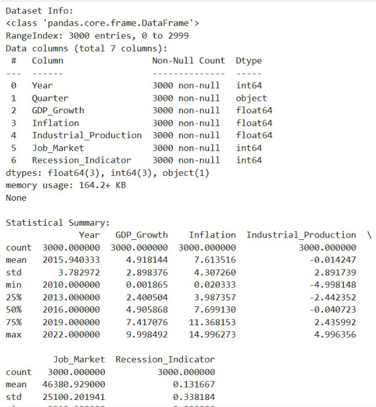

Fig. 16. 3k Dataset Composition

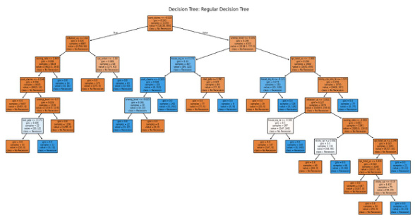

Fig. 17. Regular descision Tree

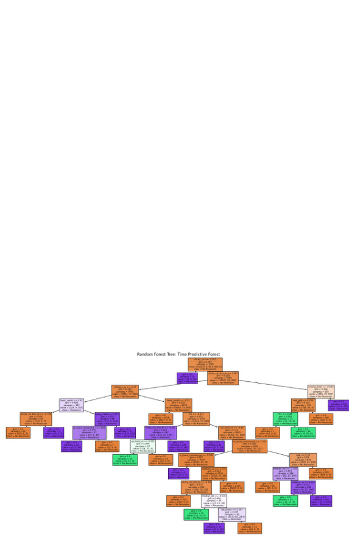

Fig. 18. Random Forest Tree: Time Predictive Forest